# Bellabeat-Case Study

Akshay Topare

2021-11-22

### Introduction

Urška Sršen and Sando Mur founded Bellabeat, a high-tech company that manufactures health-focused smart products. Sršen used her background as an artist to develop beautifully designed technology that informs and inspires women around the world. Collecting data on activity, sleep, stress, and reproductive health has allowed Bellabeat to empower women with knowledge about their own health and habits. Since it was founded in 2013, Bellabeat has grown rapidly and quickly positioned itself as a tech-driven wellness company for women.

### Business Task

Analyzing smart device fitness data could help unlock new growth opportunities for the company. Focusing on one of the Bellabeat’s products and analyze smart device data to gain insight into how consumers are using their smart devices. The insights we discover will then help guide marketing strategy for the company.

### Stakeholders

- Primary
1. Urška Sršen, cofounder and Chief Creative Officer
2. Sando Mur, cofounder
- Secondary
1. Bellabeat marketing analytics team

### Installing and loading common packages and libraries

```r
library(tidyverse)
library(lubridate)
library(sqldf)
```

```r
library(ggplot2)
```

### STEP 1: COLLECT DATA

### Loading your CSV files

Here we’ll create a dataframe named ‘daily_activity’ and read in one of the CSV files from the dataset. We’ll create another dataframes for the sleep data, daily steps and daily calories

```r
daily_activity <- read.csv("dailyActivity_merged.csv")
sleep_day <- read.csv("sleepDay_merged.csv")
daily_steps <- read.csv("dailySteps_merged.csv")
daily_calories <- read.csv("dailyCalories_merged.csv")
```

```r
head(daily_activity)
```

```
##           Id ActivityDate TotalSteps TotalDistance TrackerDistance
## 1 1503960366    4/12/2016      13162          8.50            8.50
## 2 1503960366    4/13/2016      10735          6.97            6.97
## 3 1503960366    4/14/2016      10460          6.74            6.74
## 4 1503960366    4/15/2016       9762          6.28            6.28
## 5 1503960366    4/16/2016      12669          8.16            8.16
## 6 1503960366    4/17/2016       9705          6.48            6.48
##   LoggedActivitiesDistance VeryActiveDistance ModeratelyActiveDistance
## 1                        0               1.88                     0.55
## 2                        0               1.57                     0.69
## 3                        0               2.44                     0.40
## 4                        0               2.14                     1.26
## 5                        0               2.71                     0.41
## 6                        0               3.19                     0.78
##   LightActiveDistance SedentaryActiveDistance VeryActiveMinutes
## 1                6.06                       0                25
## 2                4.71                       0                21
## 3                3.91                       0                30
## 4                2.83                       0                29
## 5                5.04                       0                36
## 6                2.51                       0                38
##   FairlyActiveMinutes LightlyActiveMinutes SedentaryMinutes Calories
## 1                  13                  328              728     1985
## 2                  19                  217              776     1797
## 3                  11                  181             1218     1776
## 4                  34                  209              726     1745
## 5                  10                  221              773     1863
## 6                  20                  164              539     1728
```

```r
head(sleep_day)
```

```
##           Id              SleepDay TotalSleepRecords TotalMinutesAsleep
## 1 1503960366 4/12/2016 12:00:00 AM                 1                327
## 2 1503960366 4/13/2016 12:00:00 AM                 2                384
## 3 1503960366 4/15/2016 12:00:00 AM                 1                412
## 4 1503960366 4/16/2016 12:00:00 AM                 2                340
## 5 1503960366 4/17/2016 12:00:00 AM                 1                700
## 6 1503960366 4/19/2016 12:00:00 AM                 1                304
##   TotalTimeInBed
## 1            346
## 2            407
## 3            442
## 4            367
## 5            712
## 6            320
```

```r
head(daily_calories)
```

```
##           Id ActivityDay Calories
## 1 1503960366   4/12/2016     1985
## 2 1503960366   4/13/2016     1797
## 3 1503960366   4/14/2016     1776
## 4 1503960366   4/15/2016     1745
## 5 1503960366   4/16/2016     1863
## 6 1503960366   4/17/2016     1728
```

```r
head(daily_steps)
```

```
##           Id ActivityDay StepTotal
## 1 1503960366   4/12/2016     13162
## 2 1503960366   4/13/2016     10735
## 3 1503960366   4/14/2016     10460
## 4 1503960366   4/15/2016      9762
## 5 1503960366   4/16/2016     12669
## 6 1503960366   4/17/2016      9705
```

### Identify all the columns in the daily_activity, sleep_day, daily_calories and daily_steps data.

```r
colnames(daily_activity)
```

```
##  [1] "Id"                       "ActivityDate"
##  [3] "TotalSteps"               "TotalDistance"
##  [5] "TrackerDistance"          "LoggedActivitiesDistance"
##  [7] "VeryActiveDistance"       "ModeratelyActiveDistance"
##  [9] "LightActiveDistance"      "SedentaryActiveDistance"
## [11] "VeryActiveMinutes"        "FairlyActiveMinutes"
## [13] "LightlyActiveMinutes"     "SedentaryMinutes"
## [15] "Calories"
```

```r
colnames(sleep_day)
```

```
## [1] "Id"                 "SleepDay"           "TotalSleepRecords"
## [4] "TotalMinutesAsleep" "TotalTimeInBed"
```

```r
colnames(daily_calories)
```

```
## [1] "Id"          "ActivityDay" "Calories"
```

```r
colnames(daily_steps)
```

```
## [1] "Id"          "ActivityDay" "StepTotal"
```

### STEP 2: CLEAN UP AND ADD DATA TO PREPARE FOR ANALYSIS

### Convert columns into appropriate data types

As we have noticed ActivityDate column in daily_activity is in character data type, let’s convert it into date similarly SleepDay column in sleep_day and ActivityDay column in both daily_calories and daily_steps

```r
daily_activity$ActivityDate <- daily_activity$ActivityDate %>% as.Date("%m/%d/%Y")
```

```r
sleep_day$SleepDay <-
  date(mdy_hms(sleep_day$SleepDay))
```

```r
daily_calories$ActivityDay <- mdy(daily_calories$ActivityDay)
```

```r
daily_steps$ActivityDay <- mdy(daily_steps$ActivityDay)
```

Let’s Check the data

```r
str(daily_activity)
```

```
## 'data.frame':    940 obs. of  15 variables:
##  $ Id                      : num  1.5e+09 1.5e+09 1.5e+09 1.5e+09 1.5e+09 ...
##  $ ActivityDate            : Date, format: "2016-04-12" "2016-04-13" ...
##  $ TotalSteps              : int  13162 10735 10460 9762 12669 9705 13019 15506 10544 9819 ...
##  $ TotalDistance           : num  8.5 6.97 6.74 6.28 8.16 ...
##  $ TrackerDistance         : num  8.5 6.97 6.74 6.28 8.16 ...
##  $ LoggedActivitiesDistance: num  0 0 0 0 0 0 0 0 0 0 ...
##  $ VeryActiveDistance      : num  1.88 1.57 2.44 2.14 2.71 ...
##  $ ModeratelyActiveDistance: num  0.55 0.69 0.4 1.26 0.41 ...
##  $ LightActiveDistance     : num  6.06 4.71 3.91 2.83 5.04 ...
##  $ SedentaryActiveDistance : num  0 0 0 0 0 0 0 0 0 0 ...
##  $ VeryActiveMinutes       : int  25 21 30 29 36 38 42 50 28 19 ...
##  $ FairlyActiveMinutes     : int  13 19 11 34 10 20 16 31 12 8 ...
##  $ LightlyActiveMinutes    : int  328 217 181 209 221 164 233 264 205 211 ...
##  $ SedentaryMinutes        : int  728 776 1218 726 773 539 1149 775 818 838 ...
##  $ Calories                : int  1985 1797 1776 1745 1863 1728 1921 2035 1786 1775 ...
```

```r
str(sleep_day)
```

```
## 'data.frame':    413 obs. of  5 variables:
##  $ Id                : num  1.5e+09 1.5e+09 1.5e+09 1.5e+09 1.5e+09 ...
##  $ SleepDay          : Date, format: "2016-04-12" "2016-04-13" ...
##  $ TotalSleepRecords : int  1 2 1 2 1 1 1 1 1 1 ...
##  $ TotalMinutesAsleep: int  327 384 412 340 700 304 360 325 361 430 ...
##  $ TotalTimeInBed    : int  346 407 442 367 712 320 377 364 384 449 ...
```

```r
str(daily_calories)
```

```
## 'data.frame':    940 obs. of  3 variables:
##  $ Id         : num  1.5e+09 1.5e+09 1.5e+09 1.5e+09 1.5e+09 ...
##  $ ActivityDay: Date, format: "2016-04-12" "2016-04-13" ...
##  $ Calories   : int  1985 1797 1776 1745 1863 1728 1921 2035 1786 1775 ...
```

```r
str(daily_steps)
```

```
## 'data.frame':    940 obs. of  3 variables:
##  $ Id         : num  1.5e+09 1.5e+09 1.5e+09 1.5e+09 1.5e+09 ...
##  $ ActivityDay: Date, format: "2016-04-12" "2016-04-13" ...
##  $ StepTotal  : int  13162 10735 10460 9762 12669 9705 13019 15506 10544 9819 ...
```

Let’s convert Id column in each dataframe into character as we are not going to do any calculations on Id

```r
daily_activity$Id <- as.character(daily_activity$Id)
sleep_day$Id <- as.character(sleep_day$Id)
daily_calories$Id <- as.character(daily_calories$Id)
daily_steps$Id <- as.character(daily_steps$Id)
```

Let’s Check The Data

```r
str(daily_activity)
```

```
## 'data.frame':    940 obs. of  15 variables:
##  $ Id                      : chr  "1503960366" "1503960366" "1503960366" "1503960366" ...
##  $ ActivityDate            : Date, format: "2016-04-12" "2016-04-13" ...
##  $ TotalSteps              : int  13162 10735 10460 9762 12669 9705 13019 15506 10544 9819 ...
##  $ TotalDistance           : num  8.5 6.97 6.74 6.28 8.16 ...
##  $ TrackerDistance         : num  8.5 6.97 6.74 6.28 8.16 ...
##  $ LoggedActivitiesDistance: num  0 0 0 0 0 0 0 0 0 0 ...
##  $ VeryActiveDistance      : num  1.88 1.57 2.44 2.14 2.71 ...
##  $ ModeratelyActiveDistance: num  0.55 0.69 0.4 1.26 0.41 ...
##  $ LightActiveDistance     : num  6.06 4.71 3.91 2.83 5.04 ...
##  $ SedentaryActiveDistance : num  0 0 0 0 0 0 0 0 0 0 ...
##  $ VeryActiveMinutes       : int  25 21 30 29 36 38 42 50 28 19 ...
##  $ FairlyActiveMinutes     : int  13 19 11 34 10 20 16 31 12 8 ...
##  $ LightlyActiveMinutes    : int  328 217 181 209 221 164 233 264 205 211 ...
##  $ SedentaryMinutes        : int  728 776 1218 726 773 539 1149 775 818 838 ...
##  $ Calories                : int  1985 1797 1776 1745 1863 1728 1921 2035 1786 1775 ...
```

```r
str(sleep_day)
```

```
## 'data.frame':    413 obs. of  5 variables:
##  $ Id                : chr  "1503960366" "1503960366" "1503960366" "1503960366" ...
##  $ SleepDay          : Date, format: "2016-04-12" "2016-04-13" ...
##  $ TotalSleepRecords : int  1 2 1 2 1 1 1 1 1 1 ...
##  $ TotalMinutesAsleep: int  327 384 412 340 700 304 360 325 361 430 ...
##  $ TotalTimeInBed    : int  346 407 442 367 712 320 377 364 384 449 ...
```

```r
str(daily_calories)
```

```
## 'data.frame':    940 obs. of  3 variables:
##  $ Id         : chr  "1503960366" "1503960366" "1503960366" "1503960366" ...
##  $ ActivityDay: Date, format: "2016-04-12" "2016-04-13" ...
##  $ Calories   : int  1985 1797 1776 1745 1863 1728 1921 2035 1786 1775 ...
```

```r
str(daily_steps)
```

```
## 'data.frame':    940 obs. of  3 variables:
##  $ Id         : chr  "1503960366" "1503960366" "1503960366" "1503960366" ...
##  $ ActivityDay: Date, format: "2016-04-12" "2016-04-13" ...
##  $ StepTotal  : int  13162 10735 10460 9762 12669 9705 13019 15506 10544 9819 ...
```

We have observed that all the data in daily_calories and daily_steps dataframe is also present in daily_activity so we can ignore these two dataframes

Let’s join tables daily_activity and sleep_day so that we can do analysis in a better way We are going to join these two tables based on Id and ActivityDate(SleepDay in sleep_day) We are going to take certain important columns from these two tables which are important for our analysis

```r
activity_sleep_combined <- sqldf("SELECT ac.Id, ac.ActivityDate, ac.TotalSteps
      , ac.TotalDistance, ac.SedentaryMinutes, ac.Calories, sl.TotalSleepRecords
      , sl.TotalMinutesAsleep, sl.TotalTimeInBed FROM daily_activity ac
      INNER JOIN sleep_day sl
      ON ac.Id = sl.Id
      AND ac.ActivityDate = sl.SleepDay")
```

The data can only be aggregated at the Id-level, which is too granular. We will want to add some additional columns of data – such as day, month that provide additional opportunities to aggregate the data.

Add columns that list the date and month of the dataframe

```r
activity_sleep_combined$day <- day(activity_sleep_combined$ActivityDate)
activity_sleep_combined$day_of_week <- weekdays(activity_sleep_combined$ActivityDate)
activity_sleep_combined$month <- month(activity_sleep_combined$ActivityDate)
```

Let’s check our data

```r
str(activity_sleep_combined)
```

```
## 'data.frame':    413 obs. of  12 variables:
##  $ Id                : chr  "1503960366" "1503960366" "1503960366" "1503960366" ...
##  $ ActivityDate      : Date, format: "2016-04-12" "2016-04-13" ...
##  $ TotalSteps        : int  13162 10735 9762 12669 9705 15506 10544 9819 14371 10039 ...
##  $ TotalDistance     : num  8.5 6.97 6.28 8.16 6.48 ...
##  $ SedentaryMinutes  : int  728 776 726 773 539 775 818 838 732 709 ...
##  $ Calories          : int  1985 1797 1745 1863 1728 2035 1786 1775 1949 1788 ...
##  $ TotalSleepRecords : int  1 2 1 2 1 1 1 1 1 1 ...
##  $ TotalMinutesAsleep: int  327 384 412 340 700 304 360 325 361 430 ...
##  $ TotalTimeInBed    : int  346 407 442 367 712 320 377 364 384 449 ...
##  $ day               : int  12 13 15 16 17 19 20 21 23 24 ...
##  $ day_of_week       : chr  "Tuesday" "Wednesday" "Friday" "Saturday" ...
##  $ month             : num  4 4 4 4 4 4 4 4 4 4 ...
```

### Note that all datasets have the ‘Id’ field - this can be used to merge the datasets.

## Understanding some summary statistics

How many unique participants are there in each dataframe? It looks like there may be more participants in the daily activity dataset than the sleep dataset.

```r
n_distinct(daily_activity$Id)
```

```
## [1] 33
```

```r
n_distinct(sleep_day$Id)
```

```
## [1] 24
```

```r
n_distinct(daily_calories$Id)
```

```
## [1] 33
```

```r
n_distinct(daily_steps$Id)
```

```
## [1] 33
```

```r
n_distinct(activity_sleep_combined$Id)
```

```
## [1] 24
```

How many observations are there in each dataframe?

```r
nrow(daily_activity)
```

```
## [1] 940
```

```r
nrow(sleep_day)
```

```
## [1] 413
```

```r
nrow(daily_calories)
```

```
## [1] 940
```

```r
nrow(daily_steps)
```

```
## [1] 940
```

```r
nrow(activity_sleep_combined)
```

```
## [1] 413
```

## STEP 3: CONDUCT DESCRIPTIVE ANALYSIS

Let’s do some quick summary statistics we’d want to know about combined data frame

For the activity_sleep_combined data frame

```r
activity_sleep_combined %>%
  select(TotalSteps,TotalDistance,SedentaryMinutes) %>%
  summary()
```

```
##    TotalSteps    TotalDistance    SedentaryMinutes
##  Min.   :   17   Min.   : 0.010   Min.   :   0.0
##  1st Qu.: 5206   1st Qu.: 3.600   1st Qu.: 631.0
##  Median : 8925   Median : 6.290   Median : 717.0
##  Mean   : 8541   Mean   : 6.039   Mean   : 712.2
##  3rd Qu.:11393   3rd Qu.: 8.030   3rd Qu.: 783.0
##  Max.   :22770   Max.   :17.540   Max.   :1265.0
```

```r
activity_sleep_combined %>%
  select(TotalSleepRecords,
         TotalMinutesAsleep,
         TotalTimeInBed) %>%
  summary()
```

```
##  TotalSleepRecords TotalMinutesAsleep TotalTimeInBed
##  Min.   :1.000     Min.   : 58.0      Min.   : 61.0
##  1st Qu.:1.000     1st Qu.:361.0      1st Qu.:403.0
##  Median :1.000     Median :433.0      Median :463.0
##  Mean   :1.119     Mean   :419.5      Mean   :458.6
##  3rd Qu.:1.000     3rd Qu.:490.0      3rd Qu.:526.0
##  Max.   :3.000     Max.   :796.0      Max.   :961.0
```

Let’s aggregate the data

Let’s aggregate based on Id

```r
aggregate(cbind(avg_TotalSteps = activity_sleep_combined$TotalSteps,
                avg_TotalDistance = activity_sleep_combined$TotalDistance,
                avg_SedentaryMinutes = activity_sleep_combined$SedentaryMinutes,
                avg_Calories = activity_sleep_combined$Calories,
                avg_TotalMinutesAsleep = activity_sleep_combined$TotalMinutesAsleep,
                avg_TotalTimeInBed=activity_sleep_combined$TotalTimeInBed)~activity_sleep_combined$Id
          , FUN = mean)
```

```
##    activity_sleep_combined$Id avg_TotalSteps avg_TotalDistance
## 1                  1503960366      12405.680          7.971200
## 2                  1644430081       7967.750          5.792500
## 3                  1844505072       3477.000          2.303333
## 4                  1927972279       1490.000          1.032000
## 5                  2026352035       5618.679          3.487143
## 6                  2320127002       5079.000          3.420000
## 7                  2347167796       8533.200          5.681333
## 8                  3977333714      11218.000          7.676071
## 9                  4020332650       6596.750          4.731250
## 10                 4319703577       7125.423          4.785769
## 11                 4388161847      10974.708          8.539167
## 12                 4445114986       4756.179          3.217500
## 13                 4558609924       8139.000          5.382000
## 14                 4702921684       9226.357          7.484286
```

[output cut: 35 more lines]

Let’s aggregate based on day_of_week

```r
aggregate(cbind(avg_TotalSteps = activity_sleep_combined$TotalSteps,
            avg_TotalDistance = activity_sleep_combined$TotalDistance,
            avg_SedentaryMinutes = activity_sleep_combined$SedentaryMinutes,
            avg_Calories = activity_sleep_combined$Calories,
            avg_TotalMinutesAsleep = activity_sleep_combined$TotalMinutesAsleep,
            avg_TotalTimeInBed=activity_sleep_combined$TotalTimeInBed)~activity_sleep_combined$day_of_week
          , FUN = mean)
```

```
##   activity_sleep_combined$day_of_week avg_TotalSteps avg_TotalDistance
## 1                              Friday       7901.404          5.511930
## 2                              Monday       9339.851          6.611064
## 3                            Saturday       9948.690          7.095690
## 4                              Sunday       7297.855          5.184727
## 5                            Thursday       8205.354          5.798154
## 6                             Tuesday       9182.692          6.430000
## 7                           Wednesday       8022.864          5.719849
##   avg_SedentaryMinutes avg_Calories avg_TotalMinutesAsleep avg_TotalTimeInBed
## 1             743.0877     2329.649               405.4211           445.0526
## 2             717.8511     2465.447               418.8298           456.1702
## 3             678.6552     2527.172               420.8103           461.2759
## 4             687.6364     2276.600               452.7455           503.5091
## 5             701.4154     2315.785               402.3692           435.8000
## 6             740.0462     2496.200               404.5385           443.2923
## 7             714.4545     2378.242               434.6818           470.0303
```

Notice that the days of the week are out of order. Let’s fix that

```r
activity_sleep_combined$day_of_week <-
  ordered(activity_sleep_combined$day_of_week,
            levels=c("Sunday", "Monday", "Tuesday", "Wednesday", "Thursday", "Friday", "Saturday"))
```

```r
aggregate(cbind(avg_TotalSteps = activity_sleep_combined$TotalSteps,
            avg_TotalDistance = activity_sleep_combined$TotalDistance,
            avg_SedentaryMinutes = activity_sleep_combined$SedentaryMinutes,
            avg_Calories = activity_sleep_combined$Calories,
            avg_TotalMinutesAsleep = activity_sleep_combined$TotalMinutesAsleep,
            avg_TotalTimeInBed = activity_sleep_combined$TotalTimeInBed)~activity_sleep_combined$day_of_week
          , FUN = mean)
```

```
##   activity_sleep_combined$day_of_week avg_TotalSteps avg_TotalDistance
## 1                              Sunday       7297.855          5.184727
## 2                              Monday       9339.851          6.611064
## 3                             Tuesday       9182.692          6.430000
## 4                           Wednesday       8022.864          5.719849
## 5                            Thursday       8205.354          5.798154
## 6                              Friday       7901.404          5.511930
## 7                            Saturday       9948.690          7.095690
##   avg_SedentaryMinutes avg_Calories avg_TotalMinutesAsleep avg_TotalTimeInBed
## 1             687.6364     2276.600               452.7455           503.5091
## 2             717.8511     2465.447               418.8298           456.1702
## 3             740.0462     2496.200               404.5385           443.2923
## 4             714.4545     2378.242               434.6818           470.0303
## 5             701.4154     2315.785               402.3692           435.8000
## 6             743.0877     2329.649               405.4211           445.0526
## 7             678.6552     2527.172               420.8103           461.2759
```

## STEP 4: ViSUALIZE THE DATA

Let’s Determine how many average steps consumers take on each day

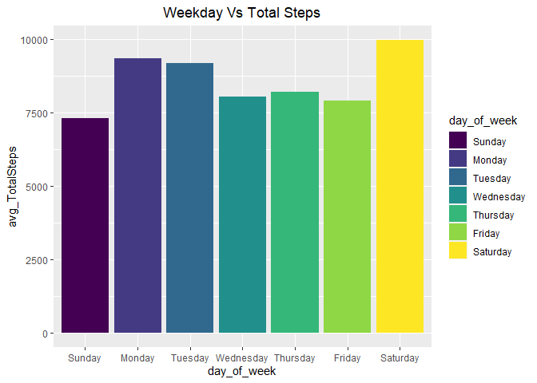

```r
activity_sleep_combined %>% group_by(day_of_week) %>%
  summarise(avg_TotalSteps = mean(TotalSteps)) %>%
  ggplot(aes(x=day_of_week,y=avg_TotalSteps,fill=day_of_week)) + geom_col() +
  labs(title = "Weekday Vs Total Steps") +
  theme(plot.title = element_text(hjust = 0.5))
```

```r
dev.copy(jpeg,filename='plot1.jpg')
```

```r
dev.off()
```

Let’s determine average distance consumers walk on each weekday

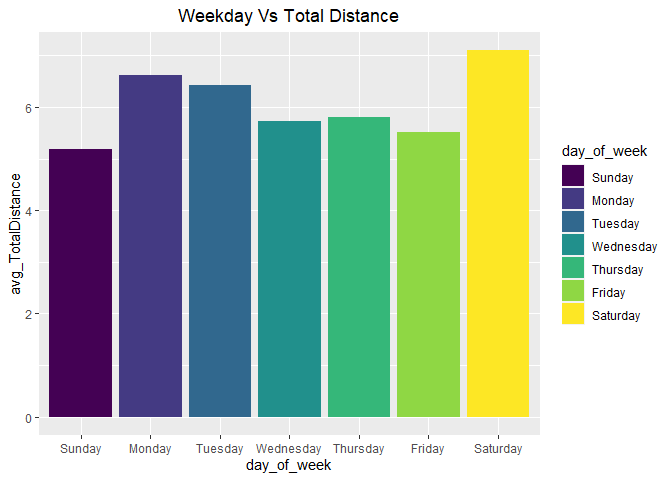

```r
activity_sleep_combined %>% group_by(day_of_week) %>%
  summarize(avg_TotalDistance = mean(TotalDistance)) %>%
  ggplot(aes(x=day_of_week,y=avg_TotalDistance,fill=day_of_week)) + geom_col() +
  labs(title = "Weekday Vs Total Distance") +
  theme(plot.title = element_text(hjust = 0.5))
```

```r
dev.copy(jpeg,filename='plot2.jpg')
```

```r
dev.off()
```

Let’s find out on average how much time consumers are seated or inactive on each weekday

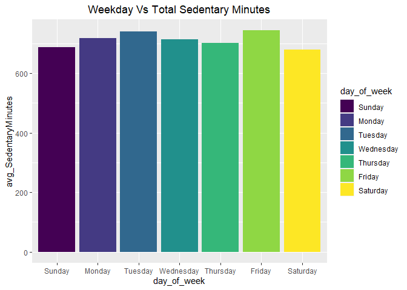

```r
activity_sleep_combined %>% group_by(day_of_week) %>%
  summarize(avg_SedentaryMinutes=mean(SedentaryMinutes)) %>%
  ggplot(aes(x=day_of_week,y=avg_SedentaryMinutes,fill=day_of_week)) + geom_col() +
  labs(title = "Weekday Vs Total Sedentary Minutes") +
  theme(plot.title = element_text(hjust = 0.5))
```

```r
dev.copy(jpeg,filename='plot3.jpg')
```

```r
dev.off()
```

Let’s find out How much calories are burned on each day of week

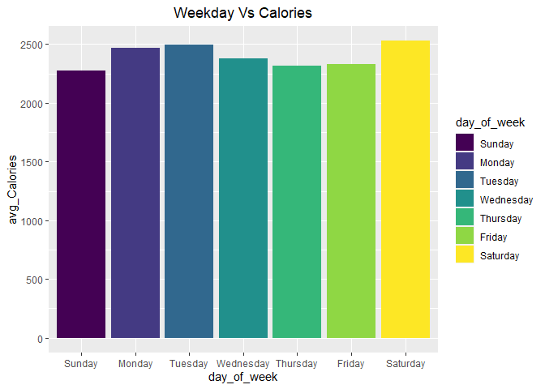

```r
activity_sleep_combined %>% group_by(day_of_week) %>%
  summarize(avg_Calories=mean(Calories)) %>%
  ggplot(aes(x=day_of_week,y=avg_Calories,fill=day_of_week)) + geom_col() +
  labs(title = "Weekday Vs Calories") +
  theme(plot.title = element_text(hjust = 0.5))
```

```r
dev.copy(jpeg,filename='plot4.jpg')
```

```r
dev.off()
```

Let’s determine sleeping habbits of consumers

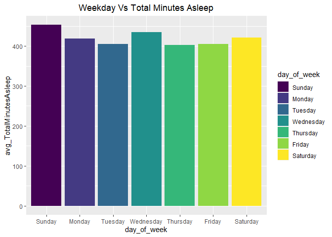

```r
activity_sleep_combined %>% group_by(day_of_week) %>%
  summarize(avg_TotalMinutesAsleep=mean(TotalMinutesAsleep)) %>%
  ggplot(aes(x=day_of_week,y=avg_TotalMinutesAsleep,fill=day_of_week)) + geom_col() +
  labs(title = "Weekday Vs Total Minutes Asleep") +
  theme(plot.title = element_text(hjust = 0.5))
```

```r
dev.copy(jpeg,filename='plot5.jpg')
```

```r
dev.off()
```

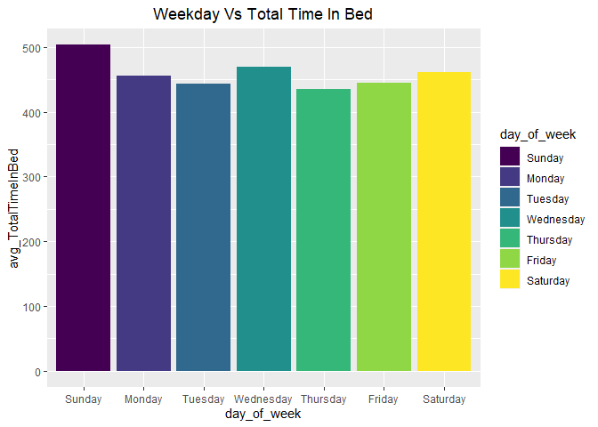

```r
activity_sleep_combined %>% group_by(day_of_week) %>%
  summarize(avg_TotalTimeInBed=mean(TotalTimeInBed)) %>%
  ggplot(aes(x=day_of_week,y=avg_TotalTimeInBed,fill=day_of_week)) + geom_col() +
  labs(title = "Weekday Vs Total Time In Bed") +
  theme(plot.title = element_text(hjust = 0.5))
```

```r
dev.copy(jpeg,filename='plot6.jpg')
```

```r
dev.off()
```

Let’s find out relationship between TotalMinutesAsleep and TotalTimeInBed

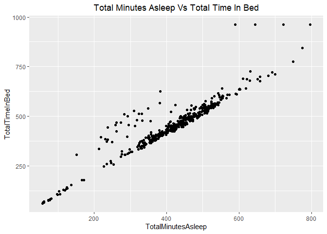

```r
activity_sleep_combined %>%
  ggplot(aes(x=TotalMinutesAsleep,y=TotalTimeInBed)) + geom_point() +
  labs(title = "Total Minutes Asleep Vs Total Time In Bed") +
  theme(plot.title = element_text(hjust = 0.5))
```

```r
dev.copy(jpeg,filename='plot7.jpg')
```

```r
dev.off()
```

What’s the relationship between steps taken in a day and sedentary minutes? How could this help inform the customer segments that we can market to? E.g. position this more as a way to get started in walking more? Or to measure steps that you’re already taking?

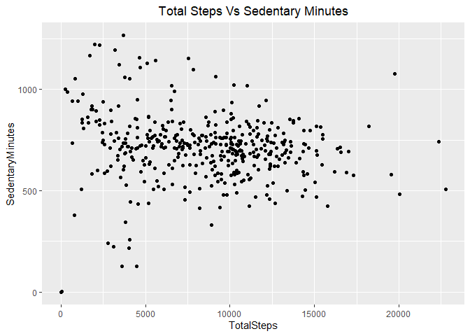

```r
activity_sleep_combined %>%
  ggplot(aes(x=TotalSteps,y=SedentaryMinutes)) + geom_point() +
  labs(title = "Total Steps Vs Sedentary Minutes") +
  theme(plot.title = element_text(hjust = 0.5))
```

```r
dev.copy(jpeg,filename='plot8.jpg')
```

```r
dev.off()
```

Let’s find out relationship between sitting or inactiveness and calories

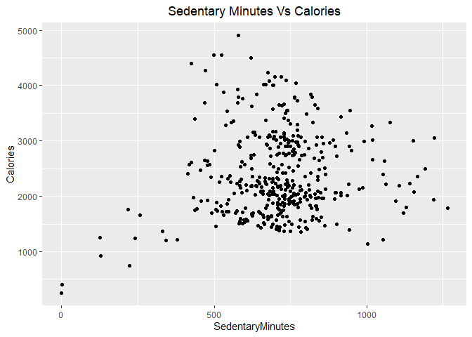

```r
activity_sleep_combined %>%
  ggplot(aes(x=SedentaryMinutes,y=Calories)) + geom_point() +
  labs(title = "Sedentary Minutes Vs Calories") +
  theme(plot.title = element_text(hjust = 0.5))
```

```r
dev.copy(jpeg,filename='plot9.jpg')
```

```r
dev.off()
```

Let’s determine relationship between number of steps and sleep

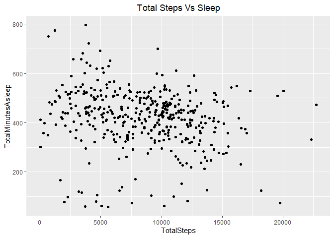

```r
activity_sleep_combined %>%
  ggplot(aes(x=TotalSteps,y=TotalMinutesAsleep)) + geom_point() +
  labs(title = "Total Steps Vs Sleep") +
  theme(plot.title = element_text(hjust = 0.5))
```

```r
dev.copy(jpeg,filename='plot10.jpg')
```

```r
dev.off()
```

STEP 5: EXPORT SUMMARY FILE FOR FURTHER ANALYSIS

```r
activity_sleep_summary <- aggregate(cbind(avg_TotalSteps = activity_sleep_combined$TotalSteps,
                avg_TotalDistance = activity_sleep_combined$TotalDistance,
                avg_SedentaryMinutes = activity_sleep_combined$SedentaryMinutes,
                avg_Calories = activity_sleep_combined$Calories,
                avg_TotalMinutesAsleep = activity_sleep_combined$TotalMinutesAsleep,
                avg_TotalTimeInBed = activity_sleep_combined$TotalTimeInBed)~activity_sleep_combined$day_of_week
          , FUN = mean)
```

Create a csv file that we will visualize in Excel, Tableau, or my presentation software

```r
write.csv(activity_sleep_summary, file = "activity_sleep_summary.csv")
```

## Recommendations

1. Bellabeat could share these findings with consumers to spread awareness about daily activities and sleeping habits and at the same time to promote how Bellabeat products could benefit the consumers to streamline these habits to make them healthier.
2. Bellabeat could promote their membership program to consumers which offers a subscription-based membership program for users. Membership gives users 24/7 access to fully personalized guidance on nutrition, activity, sleep, health and beauty, and mindfulness based on their lifestyle and goals. This could create discipline and offer healthier life.
3. Bellbeat could use personized adds to promote their products to the targeted group and make them aware that how these products could be used for health benefits.